# Chapter 1: Introduction to Nonlinear Regression and NLME Models

MI-210 Essentials of Population PKPD M&S — Pumas Edition

Author

Adapted from Marc R. Gastonguay, Ph.D. (Metrum Institute)

Published

April 18, 2026

# 1 Overview

This chapter covers the foundational concepts for population PK-PD modeling:

- Introduction to Population PKPD Modeling and Simulation
- Fitting a Model to Data: Nonlinear Regression
  - Phase 1 Exposure-Response Examples
  - Maximum Likelihood Estimation
  - Least-Squares Objective Functions
  - Diagnostics for Regression Models
- Maximum Likelihood for Population Repeated Measures Data
  - Hierarchical Mixed-Effects Models
  - Population NLMEM Objective Functions
  - Diagnostics for Population Models

# 2 Introduction to Population PKPD Modeling and Simulation

## 2.1 What is Population PK-PD?

Population pharmacokinetic-pharmacodynamic analysis aims to:

- Determine PK (PD) model structure for the population
- Estimate typical (mean) population PK (PD) parameters and inter-individual variability
- Estimate individual PK (PD) parameters
- Estimate residual (and inter-occasion) variability
- Identify measurable sources of variability and describe their relationship to PK (PD) parameters
- Study all of these in the intended patient population

**The Philosophy of Pharmacometric Modeling**

Pharmacometric analysis rests on two stacked pillars. The **lower pillar** is technical expertise — statistics, mathematics, and programming — accounting for roughly 20–30% of the analytical effort. The **upper pillar** is strategic expertise — scientific judgment, question formulation, and decision-making — which accounts for 70–80%. Without the technical foundation the strategic layer has no basis, but technical skill alone is insufficient.

The principle of **parsimony** is central: the goal is the simplest model that adequately describes the central tendency and variability of the data. Not every analysis requires a full NLME model; some questions are best answered by NCA. The complexity of the model should be commensurate with the complexity of the question.

As John Tukey observed: *“It is better to find an approximate answer to the right question than to find the right answer to an approximate question.”* Investing time in formulating the right question — grounded in knowledge of the drug, disease, and trial — is more valuable than technical precision applied to a poorly defined problem.

## 2.2 Why Population PK-PD?

**Goal:** To *understand* factors leading to variability in pharmacokinetic and pharmacodynamic response for appropriate drug use.

- Efficient way to screen large numbers of diverse individuals
- Allows investigation of multiple factors at once (drug interactions, food effects, pathophysiology, demographics)

## 2.3 Modeling and Simulation in Drug Development

**“Drug Development = Model-Building”**

- Quantitative support for decision making
- Population parameter estimation
- Transition from Phase I to Phase II/III
- Dose selection for Phase III
- Dose adjustment in special populations
- Confirm drug interaction studies
- Support for confirmatory efficacy/safety

# 3 Introduction to Nonlinear Regression Concepts

## 3.1 A Phase 1 Exposure-Response Example

A multiple cohort ascending single dose study of MI2005A. One endpoint of interest is the effect on cardiac repolarization (delta QTc vs. plasma concentration).

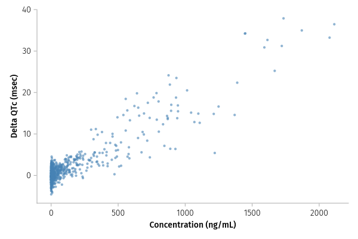

Figure 1: Figure 1.2: Delta QTc vs. Plasma MI2005a Concentration

```julia
dqtc_df = CSV.read(joinpath(data_dir, "dqtc.csv"), DataFrame)
rename!(dqtc_df, "SID" => :id, "CONC" => :conc, "dqtc" => :dqtc, "DOSE" => :dose, "TIME" => :time)

fig = Figure(size = (600, 400))
ax = Axis(fig[1, 1],
    xlabel = "Concentration (ng/mL)",
    ylabel = "Delta QTc (msec)",
)
scatter!(ax, dqtc_df.conc, dqtc_df.dqtc, color = :steelblue, markersize = 6, alpha = 0.6)
fig
```

## 3.2 Maximum Likelihood Approach

**Fitting a Model to Data:**

1. Observe data
2. Specify a model
3. Choose initial estimates for parameters
4. Obtain best estimates of parameters, given data and model
5. Evaluate model fit

### 3.2.1 Terminology

- **Dependent Variable (DV):** observed data to be described by the model (e.g., plasma concentration)
- **Independent Variable:** observed quantities used in model prediction (e.g., dose, time)
- **Covariate Factors:** other observed quantities used to explain inter-individual differences (e.g., weight, CLcr)
- **Parameters:** variables to be estimated, given the data and proposed model (e.g., CL, V)

**PK Foundations: Variables, Parameters, Constants, and Error**

A **parameter** (e.g., $k_e$, $V$) is a numerical quantity estimated from observed data that defines the relationship between independent and dependent variables within a given model. Once estimated, it is treated as fixed within that model context. A **constant** is a value held fixed from prior knowledge — for example, hepatic blood flow ($\approx 1.5$ L/hr/kg) is treated as a physiological constant in many PK models, even though it was itself originally estimated as a parameter from experimental data. This distinction is frequently conflated in the literature.

All data contain error, and this extends beyond model residuals:

- **Dependent variable error:** bioanalytical assay imprecision (typically accepted within 15–20% of nominal).
- **Independent variable error:** a nominal 2-hour sample may be collected at 2 hours and 5 minutes.
- **Covariate error:** body weight recorded from a home scale of uncertain calibration.

Identifying and characterizing these error sources *before* fitting any model is a critical and often underappreciated step in the analysis workflow.

### 3.2.2 The Likelihood Function

Let observed data $Y$ be described with parameter $\theta$. The probability $P(Y)$ can be modeled as a function of $\theta$.

The **maximum likelihood estimate (MLE)** $\hat{\theta}$ is the value of $\theta$ that maximizes $L(Y|\theta)$.

For normally-distributed measurements:

$$y_j \sim N(f(x_j, \theta), \sigma^2)$$

The **ML objective function** (equivalent to $-2\log L$ minus constants):

$$OF_{ML}(x_j, \theta, \sigma^2) = \sum_{j=1}^{n} \left[ \frac{(y_j - f(x_j, \theta))^2}{\sigma^2} + \log \sigma^2 \right]$$

## 3.3 Least-Squares Objective Functions

**Ordinary Least Squares (OLS):**

$$OF_{OLS} = \sum_{j=1}^{n} (obs_j - pred_j)^2$$

**Weighted Least Squares (WLS)** (where $W$ is typically $1/obs$):

$$OF_{WLS} = \sum_{j=1}^{n} \left[ (obs_j - pred_j)^2 \cdot W_j \right]$$

**Extended Least Squares (ELS)** (Maximum Likelihood):

$$OF_{ELS} = \sum_{j=1}^{n} \left[ \frac{(obs_j - pred_j)^2}{\sigma_j^2} + \log \sigma_j^2 \right]$$

## 3.4 1-Compartment IV Bolus Example (Excel Workbook Equivalent)

The book uses an Excel workbook to demonstrate nonlinear regression on a 1-compartment IV bolus PK model. Here we reproduce this in Julia/Pumas.

**Model:** $C_t = \frac{Dose}{V} \cdot e^{-\frac{CL}{V} \cdot t}$

**True values:** CL = 3.0 L/hr, V = 20.0 L

**The One-Compartment Model: Physiological Meaning**

The one-compartment model treats the entire body as a single, well-mixed space of volume $V$. Following an IV bolus, the drug is assumed to distribute instantaneously throughout this space, yielding an initial concentration $C_0 = \text{Dose}/V$. Thereafter, concentration declines monoexponentially according to first-order elimination:

$$C(t) = \frac{\text{Dose}}{V} \cdot e^{-k_e \cdot t}$$

where the elimination rate constant $k_e = CL/V$ is obtained from the slope of the log-linear concentration–time profile. Clearance $CL$ governs the rate of irreversible drug removal (units: volume/time), while $V$ relates the amount of drug in the body to the measured plasma concentration. On a semi-logarithmic plot, a straight line confirms monoexponential decline and supports the one-compartment assumption. Deviations from linearity (e.g., a biphasic decline) indicate distribution into peripheral tissues and motivate multi-compartment models.

```julia
# Simulate data from 1-cpt IV bolus (as in the Excel workbook)
# True parameters: CL=3, V=20, Dose=1000, additive sigma=0.9

true_CL = 3.0
true_V = 20.0
dose = 1000.0

times = [1, 2, 3, 4, 5, 6, 7, 8, 10, 12, 14, 16, 18, 19]
true_conc = @. dose / true_V * exp(-true_CL / true_V * times)

# Add noise (from book's dataset — heteroscedastic, proportional to prediction)
using Random
Random.seed!(210)
obs_conc = true_conc .+ randn(length(times)) .* (0.9 .* sqrt.(true_conc))

pk_data = DataFrame(
    time = Float64.(times),
    obs = obs_conc,
    pred_true = true_conc,
)
```

14×3 DataFrame

| Row | time Float64 | obs Float64 | pred_true Float64 |
| --- | --- | --- | --- |
| 1 | 1.0 | 47.1589 | 43.0354 |
| 2 | 2.0 | 34.7978 | 37.0409 |
| 3 | 3.0 | 24.1227 | 31.8814 |
| 4 | 4.0 | 26.7429 | 27.4406 |
| 5 | 5.0 | 17.734 | 23.6183 |
| 6 | 6.0 | 17.3789 | 20.3285 |
| 7 | 7.0 | 16.0105 | 17.4969 |
| 8 | 8.0 | 9.12062 | 15.0597 |
| 9 | 10.0 | 11.3269 | 11.1565 |
| 10 | 12.0 | 11.0079 | 8.26494 |
| 11 | 14.0 | 8.23576 | 6.12282 |
| 12 | 16.0 | 2.58291 | 4.5359 |
| 13 | 18.0 | 0.99968 | 3.36028 |
| 14 | 19.0 | -1.29063 | 2.89222 |

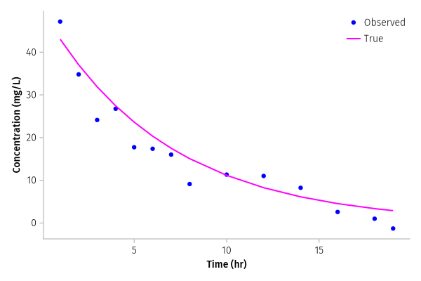

Figure 2: Observed vs. Predicted Concentration-Time Profile

```julia
fig = Figure(size = (600, 400))
ax = Axis(fig[1, 1], xlabel = "Time (hr)", ylabel = "Concentration (mg/L)")
scatter!(ax, pk_data.time, pk_data.obs, label = "Observed", color = :blue)
lines!(ax, pk_data.time, pk_data.pred_true, label = "True", color = :magenta, linewidth = 2)
axislegend(ax, position = :rt)
fig
```

### 3.4.1 OLS Estimation in Pumas

We fit the 1-cpt IV bolus model using Pumas to find the MLE of CL and V.

```julia
# Create a Pumas-compatible dataset
# Single subject, IV bolus at time 0
ols_df = DataFrame(
    id = fill(1, length(times) + 1),
    time = vcat(0.0, Float64.(times)),
    dv = vcat(missing, obs_conc),
    amt = vcat(dose, fill(0.0, length(times))),
    evid = vcat(1, fill(0, length(times))),
    cmt = fill(1, length(times) + 1),
)

ols_pop = read_pumas(ols_df)
```

```
Population
  Subjects: 1
  Observations: dv
```

```julia
# 1-compartment IV bolus model with additive error
pk_model_add = @model begin
    @param begin
        tvCL ∈ RealDomain(lower = 0.0, init = 5.0)
        tvV  ∈ RealDomain(lower = 0.0, init = 30.0)
        σ    ∈ RealDomain(lower = 0.0, init = 1.0)
    end

    @pre begin
        CL = tvCL
        Vc = tvV
    end

    @dynamics Central1

    @derived begin
        cp := @. Central / Vc
        dv ~ @. Normal(cp, σ)
    end
end
```

```
PumasModel
  Parameters: tvCL, tvV, σ
  Random effects:
  Covariates:
  Dynamical system variables: Central
  Dynamical system type: Closed form
  Derived: dv
  Observed: dv
```

```julia
ols_params = (tvCL = 5.0, tvV = 30.0, σ = 1.0)
ols_fit = fit(pk_model_add, ols_pop, ols_params, Pumas.NaivePooled())
ols_fit
```

[output not shown]

```
FittedPumasModel

Dynamical system type:                 Closed form

Number of subjects:                              1

Observation records:         Active        Missing
    dv:                          14              0
    Total:                       14              0

Number of parameters:      Constant      Optimized
                                  0              3

Likelihood approximation:              NaivePooled
Likelihood optimizer:                         BFGS

Termination Reason:                   GradientNorm
Log-likelihood value:                   -35.878724

----------------
       Estimate
----------------
tvCL    3.5122
tvV    19.451
σ       3.1388
----------------
```

### 3.4.2 Proportional Error Model (WLS equivalent)

```julia
pk_model_prop = @model begin
    @param begin
        tvCL  ∈ RealDomain(lower = 0.0, init = 5.0)
        tvV   ∈ RealDomain(lower = 0.0, init = 30.0)
        σprop ∈ RealDomain(lower = 0.0, init = 0.2)
    end

    @pre begin
        CL = tvCL
        Vc = tvV
    end

    @dynamics Central1

    @derived begin
        cp := @. Central / Vc
        dv ~ @. Normal(cp, abs(cp) * σprop)
    end
end

prop_params = (tvCL = 5.0, tvV = 30.0, σprop = 0.2)
prop_fit = fit(pk_model_prop, ols_pop, prop_params, Pumas.NaivePooled())
prop_fit
```

[output not shown]

```
FittedPumasModel

Dynamical system type:                 Closed form

Number of subjects:                              1

Observation records:         Active        Missing
    dv:                          14              0
    Total:                       14              0

Number of parameters:      Constant      Optimized
                                  0              3

Likelihood approximation:              NaivePooled
Likelihood optimizer:                         BFGS

Termination Reason:                   GradientNorm
Log-likelihood value:                   -44.124954

-----------------
        Estimate
-----------------
tvCL     3.8249
tvV     28.052
σprop    0.5361
-----------------
```

## 3.5 Diagnostic Plots for Regression Models

Standard diagnostic plots for evaluating model fit:

```
[ Info: Calculating predictions.
[ Info: Calculating weighted residuals.
[ Info: Calculating empirical bayes.
[ Info: Evaluating dose control parameters.
[ Info: Evaluating individual parameters.
[ Info: Done.
```

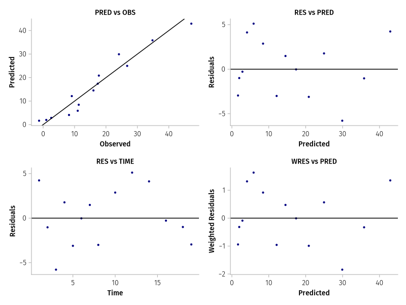

Figure 3: Diagnostic Plots for Additive Error Model

```julia
insp = inspect(ols_fit)
insp_df = DataFrame(insp)
obs_rows = @rsubset(insp_df, !ismissing(:dv))

fig = Figure(size = (800, 600))

# PRED vs OBS
ax1 = Axis(fig[1, 1], xlabel = "Observed", ylabel = "Predicted", title = "PRED vs OBS")
scatter!(ax1, obs_rows.dv, obs_rows.dv_pred, color = :navy, markersize = 6)
ablines!(ax1, 0, 1, color = :black)

# RES vs PRED
ax2 = Axis(fig[1, 2], xlabel = "Predicted", ylabel = "Residuals", title = "RES vs PRED")
res = obs_rows.dv .- obs_rows.dv_pred
scatter!(ax2, obs_rows.dv_pred, res, color = :navy, markersize = 6)
hlines!(ax2, 0, color = :black)

# RES vs TIME
ax3 = Axis(fig[2, 1], xlabel = "Time", ylabel = "Residuals", title = "RES vs TIME")
scatter!(ax3, obs_rows.time, res, color = :navy, markersize = 6)
hlines!(ax3, 0, color = :black)

# WRES vs PRED
ax4 = Axis(fig[2, 2], xlabel = "Predicted", ylabel = "Weighted Residuals", title = "WRES vs PRED")
wres = res ./ coef(ols_fit).σ
scatter!(ax4, obs_rows.dv_pred, wres, color = :navy, markersize = 6)
hlines!(ax4, 0, color = :black)

fig
```

### 3.5.1 Results Comparison: Heteroscedastic Data

The book compares parameter estimates across estimation methods:

| Parameter | LR | OLS | WLS | ELS | True |
| --- | --- | --- | --- | --- | --- |
| CL (L/hr) | 3.18 | 3.11 | 3.28 | 3.09 | 3.00 |
| V (L) | 25.52 | 24.82 | 25.14 | 25.30 | 20.00 |

# 4 Practice Problems

## 4.1 Problem 1.1: Delta QTc Concentration-Response

```julia
# Keep original subject IDs — NaivePooled estimation ignores grouping structure
# Use row index within each subject as the time axis (CONC is the covariate)
dqtc_pool = DataFrame(
    id = dqtc_df.id,
    conc = Float64.(dqtc_df.conc),
    dv = Float64.(dqtc_df.dqtc),
)
dqtc_pool.time = Vector{Float64}(undef, nrow(dqtc_pool))
for gdf in groupby(dqtc_pool, :id)
    gdf.time .= Float64.(1:nrow(gdf))
end

dqtc_pop = read_pumas(
    dqtc_pool;
    observations = [:dv],
    covariates = [:conc],
    event_data = false,
)
```

```
Population
  Subjects: 64
  Covariates: conc
  Observations: dv
```

```julia
# Linear model: dQTc = intercept + slope * CONC
linear_dqtc = @model begin
    @param begin
        tvINT ∈ RealDomain(init = 1.0)
        tvSLP ∈ RealDomain(init = 0.02)
        σ_add ∈ RealDomain(lower = 0.0, init = 5.0)
    end

    @covariates conc

    @pre begin
        INT = tvINT
        SLP = tvSLP
    end

    @derived begin
        mu := @. INT + SLP * conc
        dv ~ @. Normal(mu, σ_add)
    end
end

lin_params = (tvINT = 1.0, tvSLP = 0.02, σ_add = 5.0)
lin_fit = fit(linear_dqtc, dqtc_pop, lin_params, Pumas.NaivePooled())
lin_fit
```

[output not shown]

```
FittedPumasModel

Dynamical system type:          No dynamical model

Number of subjects:                             64

Observation records:         Active        Missing
    dv:                         812              0
    Total:                      812              0

Number of parameters:      Constant      Optimized
                                  0              3

Likelihood approximation:              NaivePooled
Likelihood optimizer:                         BFGS

Termination Reason:                   GradientNorm
Log-likelihood value:                   -1783.2424

------------------
        Estimate
------------------
tvINT   -0.088942
tvSLP    0.016926
σ_add    2.1753
------------------
```

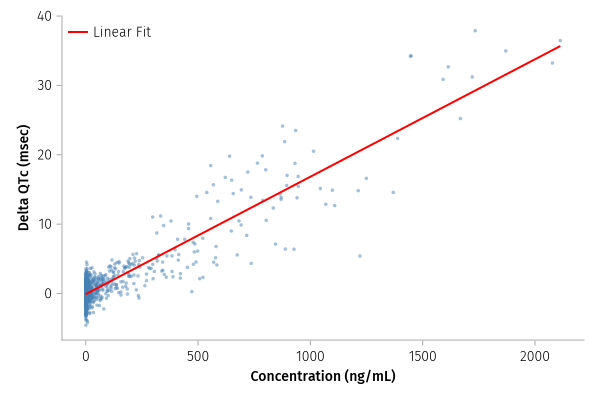

Figure 4: Problem 1.1: Linear Model Fit to Delta QTc Data

```julia
lin_coefs = coef(lin_fit)
conc_range = range(0, maximum(dqtc_df.conc), length = 100)
pred_dqtc = lin_coefs.tvINT .+ lin_coefs.tvSLP .* conc_range

fig = Figure(size = (600, 400))
ax = Axis(fig[1, 1], xlabel = "Concentration (ng/mL)", ylabel = "Delta QTc (msec)")
scatter!(ax, dqtc_df.conc, dqtc_df.dqtc, color = :steelblue, markersize = 5, alpha = 0.5)
lines!(ax, collect(conc_range), pred_dqtc, color = :red, linewidth = 2, label = "Linear Fit")
axislegend(ax, position = :lt)
fig
```

## 4.2 Problem 1.2: AST Concentration-Response (Emax)

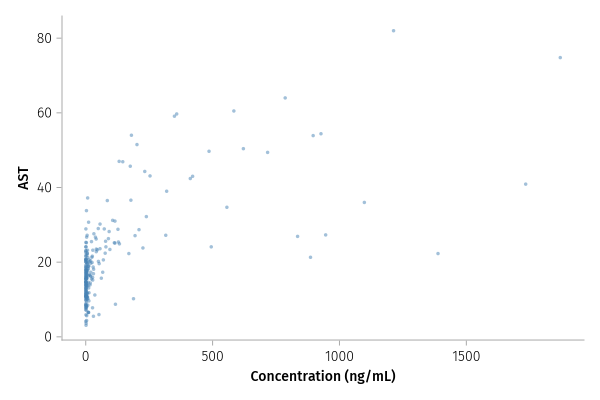

```julia
ast_df = CSV.read(joinpath(data_dir, "ast.csv"), DataFrame)
rename!(ast_df, "SID" => :id, "CONC" => :conc, "AST" => :ast, "DOSE" => :dose, "TIME" => :time)

fig = Figure(size = (600, 400))
ax = Axis(fig[1, 1], xlabel = "Concentration (ng/mL)", ylabel = "AST")
scatter!(ax, ast_df.conc, ast_df.ast, color = :steelblue, markersize = 5, alpha = 0.5)
fig
```

```julia
# Keep original subject IDs, use row index as time
ast_pool = DataFrame(
    id = ast_df.id,
    conc = Float64.(ast_df.conc),
    dv = Float64.(ast_df.ast),
)
ast_pool.time = Vector{Float64}(undef, nrow(ast_pool))
for gdf in groupby(ast_pool, :id)
    gdf.time .= Float64.(1:nrow(gdf))
end

ast_pop = read_pumas(
    ast_pool;
    observations = [:dv],
    covariates = [:conc],
    event_data = false,
)

# Emax model: AST = E0 + Emax*CONC/(EC50 + CONC)
emax_ast = @model begin
    @param begin
        tvE0   ∈ RealDomain(init = 15.0)
        tvEmax ∈ RealDomain(init = 50.0)
        tvEC50 ∈ RealDomain(lower = 0.0, init = 200.0)
        σ_add  ∈ RealDomain(lower = 0.0, init = 5.0)
    end

    @covariates conc

    @pre begin
        E0   = tvE0
        Emax = tvEmax
        EC50 = tvEC50
    end

    @derived begin
        mu := @. E0 + Emax * conc / (EC50 + conc)
        dv ~ @. Normal(mu, σ_add)
    end
end

emax_params = (tvE0 = 15.0, tvEmax = 50.0, tvEC50 = 200.0, σ_add = 5.0)
emax_fit = fit(emax_ast, ast_pop, emax_params, Pumas.NaivePooled())
emax_fit
```

[output not shown]

[output cut: 12 more lines]

[output not shown]

```
FittedPumasModel

Dynamical system type:          No dynamical model

Number of subjects:                             64

Observation records:         Active        Missing
    dv:                         235              0
    Total:                      235              0

Number of parameters:      Constant      Optimized
                                  0              4

Likelihood approximation:              NaivePooled
Likelihood optimizer:                         BFGS

Termination Reason:                   GradientNorm
Log-likelihood value:                   -826.38119

------------------
         Estimate
------------------
tvE0      14.485
tvEmax    40.351
tvEC50   207.26
σ_add      8.1464
------------------
```

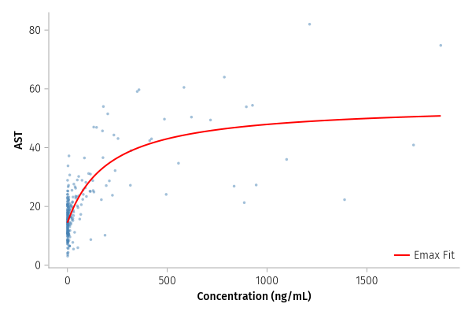

Figure 5: Problem 1.2: Emax Model Fit to AST Data

```julia
emax_coefs = coef(emax_fit)
conc_range_ast = range(0, maximum(ast_df.conc), length = 200)
pred_ast = emax_coefs.tvE0 .+ emax_coefs.tvEmax .* conc_range_ast ./ (emax_coefs.tvEC50 .+ conc_range_ast)

fig = Figure(size = (600, 400))
ax = Axis(fig[1, 1], xlabel = "Concentration (ng/mL)", ylabel = "AST")
scatter!(ax, ast_df.conc, ast_df.ast, color = :steelblue, markersize = 5, alpha = 0.5)
lines!(ax, collect(conc_range_ast), pred_ast, color = :red, linewidth = 2, label = "Emax Fit")
axislegend(ax, position = :rb)
fig
```

# 5 Maximum Likelihood Models for Population Repeated Measures Data

## 5.1 Data for Population Analyses

**Dependent Variable Types:**

- **Continuous:** concentrations, blood pressure, weight
- **Categorical:** dichotomous, ordered, counts, time-to-event

**Data Terminology:**

- **Repeated Measures:** more than one observation per individual
- **Longitudinal:** repeated measures over time
- **Sparse:** too few samples per individual
- **Extensive:** enough samples per individual

## 5.2 Hierarchical Population Mixed-Effects Models

### 5.2.1 Population PK Analysis Methods

| Method | Description |
| --- | --- |
| Naive Pooled | Treat all data as from single individual |
| Naive Averaged | Average concentrations across individuals at each time |
| Standard Two-Stage | Individual fits, then summarize across subjects |
| MAP Bayesian | Empirical Bayes estimates with population prior |
| Nonlinear Mixed-Effects | Simultaneous estimation of fixed + random effects |

### 5.2.2 Random Effects Hierarchy

A typical population PK model has two levels of random effects:

**Level 1 — Inter-Individual Variability:**
$$CL_i = TVCL \cdot e^{\eta_{CL,i}}$$

**Level 2 — Residual Variability:**
$$y_{ij} = f_{ij}(\theta, \eta_i) + \varepsilon_{ij}$$

where $\eta \sim N(0, \omega^2)$ and $\varepsilon \sim N(0, \sigma^2)$.

**Understanding Random Effects: What η Really Means**

The random effect $\eta_i$ captures the deviation of individual $i$ from the population mean. By construction, $\eta \sim \mathcal{N}(0, \omega^2)$, so its mean is zero — it represents a *deviation*, not an absolute value. A critical principle: **$\eta$ will be whatever it needs to be to match the observed data.** The optimizer does not have knowledge of the underlying physiology; it simply assigns each subject the $\eta$ that minimizes the objective function, even if that value falls far outside the assumed normal distribution.

The three common IIV parameterizations differ in what they imply about the distribution of the parameter itself:

| Parameterization | Equation | Implied Distribution of $CL_i$ |
| --- | --- | --- |
| Additive | $CL_i = TVCL + \eta_i$ | Normal — allows $CL_i < 0$ |
| Proportional | $CL_i = TVCL \cdot (1 + \eta_i)$ | Normal — allows $CL_i < 0$ for large negative $\eta$ |
| Exponential | $CL_i = TVCL \cdot e^{\eta_i}$ | Log-normal — constrains $CL_i > 0$ |

The **exponential parameterization** is preferred in practice because physiological parameters such as clearance and volume are strictly positive. The log-normal distribution enforced by the exponential form guarantees this constraint without requiring additional boundary handling in the optimizer.

### 5.2.3 Inter-Individual Variance Models

| Model | Equation | Distribution |
| --- | --- | --- |
| Additive | $CL_i = TVCL + \eta_i$ | Normal CL |
| Proportional | $CL_i = TVCL \cdot (1 + \eta_i)$ | Normal CL |
| Exponential | $CL_i = TVCL \cdot e^{\eta_i}$ | Log-Normal CL |

**Log-Normal Parameterization: Five Equivalent Forms**

The exponential IIV model ($CL_i = TVCL \cdot e^{\eta_i}$) is the most common in population PK because it constrains CL > 0. There are **five mathematically equivalent** ways to code this in Pumas:

1. **Exponentiated Normal η** (most common): `CL = tvCL * exp(η)` where `η ~ Normal(0, ω²)`
2. **LogNormal random effect**: `CL = tvCL * exp(η)` where `η ~ LogNormal(0, ω²)` — Pumas handles the transform
3. **Explicit log transform**: `CL = exp(log(tvCL) + η)` where `η ~ Normal(0, ω²)`
4. **Model on log scale**: `logCL = tvlogCL + η`, then `CL = exp(logCL)` — useful when literature reports log-scale parameters
5. **Direct LogNormal**: `CL ~ LogNormal(log(tvCL), ω)` in `@random`

All five produce identical distributions. Choose based on:

- **Form 1** is standard and keeps η accessible for EBE diagnostics
- **Forms 3–4** are useful when initial estimates are on the log scale
- **%CV interpretation**: for small ω (< 0.3), ω ≈ CV; for larger ω, $CV = \sqrt{e^{\omega^2} - 1}$

### 5.2.4 Residual Variance Models

| Model | Equation | Pumas `@derived` |
| --- | --- | --- |
| Additive | $Y_{ij} = F_{ij} + \varepsilon$ | `dv ~ Normal(pred, sigma_add)` |
| Proportional | $Y_{ij} = F_{ij} \cdot (1 + \varepsilon)$ | `dv ~ Normal(pred, abs(pred) * sigma_prop)` |
| Combined | $Y_{ij} = F_{ij}(1+\varepsilon_1) + \varepsilon_2$ | `dv ~ Normal(pred, sqrt(sigma_add^2 + (pred*sigma_prop)^2))` |

## 5.3 Population NLMEM Objective Functions

### 5.3.1 Estimation Methods in Pumas (vs. NONMEM)

| NONMEM | Pumas | Description |
| --- | --- | --- |
| METHOD=0 (FO) | `Pumas.FO()` | First-Order, $\eta=0$ |
| METHOD=1 (FOCE) | `Pumas.FOCE()` | First-Order Conditional, $\eta=\hat\eta_i$ |
| METHOD=1 INTER | `Pumas.FOCEI()` | FOCE with $\eta$-$\varepsilon$ interaction |
| METHOD=1 LAPLACIAN | `Pumas.LaplaceI()` | Laplacian approximation |

**Tip**

In Pumas, FOCEI is the recommended default for most population models. Use `LaplaceI()` for models with non-normal likelihoods (e.g., discrete, time-to-event).

**Additional Estimation Methods in Pumas**

Beyond the classical NONMEM-equivalent methods, Pumas provides:

| Method | Pumas | When to Use |
| --- | --- | --- |
| MAP Bayesian | `Pumas.MAP()` | Individual estimation with informative priors |
| Full Bayesian MCMC | `Pumas.BayesMCMC()` | Small datasets, prior information, uncertainty quantification |
| Variational EM (VEM) | `Pumas.VEM()` | Discrete/censored/TTE likelihoods, large populations |

VEM uses variational inference to approximate the posterior — it avoids the inner/outer loop of FOCE and handles non-standard likelihoods natively. See the [VEM tutorial](https://tutorials.pumas.ai/html/estimation/01-vem-introduction.html) for details.

## 5.4 Diagnostics for Population NLME Models

Key diagnostics include:

- **Minimum Objective Function Value** (-2LL)
- **Parameter Estimates** (fixed effects, random effects)
- **Standard Errors** (from `infer()`)
- **Shrinkage** (eta-shrinkage, epsilon-shrinkage)
- **Diagnostic Plots:** DV vs PRED, DV vs IPRED, CWRES vs PRED, CWRES vs TIME
- **AIC:** $AIC = 2p + (-2\log L)$ — lower is better
- **Likelihood Ratio Test:** $\Delta OFV \sim \chi^2(df = \Delta p)$

**The Pumas Modeling Workflow**

The complete Pumas workflow follows a systematic pipeline:

1. **Define model** — `@model` macro with `@param`, `@random`, `@pre`, `@dynamics`, `@derived`
2. **Prepare data** — `read_pumas()` to create a `Population` from a DataFrame
3. **Fit** — `fit(model, population, init_params, algorithm)` → returns fitted model
4. **Infer** — `infer(fit)` → confidence intervals, RSE, standard errors via `coeftable()`
5. **Inspect** — `inspect(fit)` → residuals, predictions, individual estimates
6. **Diagnose** — `goodness_of_fit(inspect_result)` → standard 4-panel GOF plot
7. **Compare** — `metrics_table(fit1, fit2)` → AIC, BIC, -2LL side by side; `lrtest(fit1, fit2)` for nested models
8. **Predict/Simulate** — `predict()` / `simobs()` → VPCs via `vpc()` + `vpc_plot()`

Each step builds on the previous. The `inspect()` result is reusable across diagnostics, GOF plots, and individual fits — compute it once and pass it around.

### 5.4.1 WRES vs. CWRES

- **WRES** (Weighted Residuals): appropriate for FO estimation only
- **CWRES** (Conditional Weighted Residuals): appropriate for conditional estimation (FOCE, FOCEI, Laplacian)

**Important**

In Pumas, `inspect()` automatically computes the appropriate weighted residuals based on the estimation method used.

## 5.5 AIC Example

```julia
# Compare additive vs proportional error for dQTc linear model

# Proportional error model
linear_dqtc_prop = @model begin
    @param begin
        tvINT  ∈ RealDomain(init = 1.0)
        tvSLP  ∈ RealDomain(init = 0.02)
        σprop  ∈ RealDomain(lower = 0.0, init = 0.3)
    end

    @covariates conc

    @pre begin
        INT = tvINT
        SLP = tvSLP
    end

    @derived begin
        mu := @. INT + SLP * conc
        dv ~ @. Normal(mu, abs(mu) * σprop + 1e-6)
    end
end

prop_lin_params = (tvINT = 1.0, tvSLP = 0.02, σprop = 0.3)
prop_lin_fit = fit(linear_dqtc_prop, dqtc_pop, prop_lin_params, Pumas.NaivePooled())

println("AIC (Additive):     ", aic(lin_fit))
println("AIC (Proportional): ", aic(prop_lin_fit))
println("\nLower AIC = better fit to the data")
```

[output not shown]

[output cut: 18 more lines]

```
 * time: 0.39846181869506836
    28     1.720033e+03     2.025641e+01
 * time: 0.3985908031463623
    29     1.720031e+03     4.867382e+01
 * time: 0.39872288703918457
    30     1.720031e+03     5.000592e+00
 * time: 0.39885401725769043
    31     1.720031e+03     1.181640e-01
 * time: 0.3989880084991455
    32     1.720031e+03     4.234472e-04
 * time: 0.39911794662475586
AIC (Additive):     3572.4847816578085
AIC (Proportional): 3446.0617056462706

Lower AIC = better fit to the data
```

# 6 Study Guide Questions

1. Which diagnostic plot is most informative about the pattern of residual error variability?
2. Which diagnostic plot is most informative about the performance of the modeling strategy with respect to residual error variance?
3. What are some strategies for detecting and avoiding local minima?
4. What are the distributional assumptions associated with the maximum likelihood objective function?
5. Can Maximum Likelihood methods be accurately applied to continuous data that are non-normally distributed?
6. Describe the key assumptions made in the FO approximation.
7. What is the eta-epsilon interaction?
8. If ETABAR is not significantly different from zero, does that indicate that underlying assumptions about inter-individual random effects have been met?

# 7 Supplementary Material

The following tutorials from PumasTutorials.jl expand on topics introduced in this chapter:

| Topic | Tutorial | Key Additions |
| --- | --- | --- |
| **Lecture: PK Terminology & Data** | PK W1a | Variables, parameters, constants, and the concept of error in PK data |
| **Lecture: Modeling Philosophy** | PKPD W1 | Two pillars of pharmacometrics, parsimony, asking the right question |
| **Lecture: Structural Models & Estimation** | PKPD W2 | Model building principles, estimation approaches, FO/FOCE/Laplacian |
| **Lecture: PopPK Model Components & NLME** | PKPD W4 | Structural/variability/covariate submodels, η and ε distributions |
| **Lecture: 1-Cpt IV Bolus Model** | PK W2 | Monoexponential decline, ke, half-life, the model behind the code |
| End-to-end PK workflow | [Introduction](https://tutorials.pumas.ai/html/introduction/introduction.html) | NCA → 1-cpt → 2-cpt → model comparison → VPC, all in one analysis |
| Pumas model syntax deep dive | [Fitting](https://tutorials.pumas.ai/html/introduction/fitting.html) | Domain types (`RealDomain`, `PDiagDomain`, `PSDDomain`), `@param`/`@random`/`@pre`/`@dynamics`/`@derived` block details |
| Dynamical system specification | [Dynamical Systems](https://tutorials.pumas.ai/html/introduction/dynamical_systems.html) | 9 equivalent ways to code the same model: closed-form, explicit ODE, ModelingToolkit, Catalyst reactions — with linearity detection |
| Log-normal vs. normal parameterization | [Log vs Normal](https://tutorials.pumas.ai/html/introduction/logvsnorm.html) | 5 equivalent Pumas code forms for exponential IIV, with simulation proof of equivalence |
| NONMEM OFV comparison | [Comparing NONMEM & Pumas](https://tutorials.pumas.ai/html/NONMEMtoPumas/comparing_NONMEM_Pumas.html) | Exact relationship: `-2*loglikelihood(fit) == OFV_with_constant`; adjustment formula and troubleshooting |